# R: Correlation and Simple Linear Regression

ITAO 20200: Statistical Inference in Business

J. S. Akosa, F. Bilson Darku, J. Waddell, & M. O’Callaghan

## Description

Simple Linear Regression is used to predict the value of a quantitative dependent (or outcome) variable $y$ based on an independent variable $x$. The aim is to establish a mathematical model (or formula) that defines $y$ as a function of the $x$ variable. At the population level, the mathematical equation can be generalized as
$$y = \beta_0 + \beta_1 x +
\varepsilon,$$
where

- $\beta_0$ is the intercept
- $\beta_1$ is the slope and
- $\varepsilon$ is the error term.

There are two main components to the model: $\beta_0 + \beta_1 x$ and $\varepsilon$. $E(y) = \beta_0 + \beta_1 x$ is the mean value of $y$ at a given value of $x$. This is the actual line of the model. $\varepsilon$ (the Greek letter epsilon) is the inherent variability in the data that occurs no matter how accurately we try to model the relationship between the two variables. This is the variability in the dependent variable that the regression model is unable to explain. Collectively, $\beta_0$ and $\beta_1$ are the **regression coefficients**.

When we have a random sample of $n$ pairs of measurements on both $x$ and $y$ variables, we can estimate the line portion of the model. The estimated model is given by
$$\hat{y} = b_0 + b_1 x$$
or for a standardized regression model:
$$\hat{Z}_y =
\beta (Z_x)$$

The estimated model can then be used to predict future values of the outcome variable $y$ for new values of the independent variable $x$.

## Assumptions

Only one independent and one dependent variable are used to estimate a simple linear regression model. The dependent variable should be measured on an interval or ratio scale. The errors should be independent and normally distributed with a mean of zero and constant variance. That is, no matter what the value of $x$ is, the variance of the errors should be the same.

## Data Entry

For this model, two separate variable columns must be created, one for the dependent variable and the other for the independent variable. To begin with, we will use the `Housing Prices.csv` data. There are four variables in this data set. **SqrFoot**, **Age**, and **Bedrooms** provide characteristics of a house while **Price** provides information about the asking price of the house. We wish to predict the asking price of a house based on the number of bedrooms in that house. Thus, our dependent variable is **Price** and our independent variable is **Bedrooms**. A portion of the data is given below.

```r
Housing <- read.csv("https://mendoza-stats.s3.amazonaws.com/housingprices.csv")
head(Housing, n = 5)
```

```
##    Price SqrFoot Age Bedrooms
## 1  90300    1700  14        3
## 2 150500    1518  27        3
## 3 269500    2708  22        4
## 4  98000     830  15        1
## 5 244650    2550  28        4
```

```r
tail(Housing, n = 5)
```

```
##     Price SqrFoot Age Bedrooms
## 27 202650    2927   1        4
## 28 195600    2843   1        4
## 29 192500    2800   1        4
## 30 166600    2439   1        3
## 31 245000    3600   3        4
```

## Data Analysis and Output

Our objective is to determine if a linear relationship exists between the asking price of a house and the number of bedrooms in that house. If this relationship exists, we want to model the relationship and use the model to predict the asking price of a future house based on the number of bedrooms in that house.

### Some Basic Descriptive Statistics

Let’s obtain some basic descriptive statistics on our two variables. We will use the `sapply()` function in base R to compute the sample size, mean, standard deviation, minimum, and maximum of each variable. (No extra packages are needed.) For our data, we have:

```r
sapply(Housing[, c("Price", "Bedrooms")],   # the variables we want to describe
       function(x) c(n = length(x),         # sample size
                     mean = mean(x),        # sample mean
                     sd = sd(x),            # sample standard deviation
                     min = min(x),          # minimum
                     max = max(x)))         # maximum
```

```
##       Price Bedrooms
## n        31  31.0000
## mean 202565   3.7419
## sd    67857   0.9989
## min   77000   1.0000
## max  315000   6.0000
```

Each column of the output describes one variable. For example, the `Price` column gives the number of houses in the data set, the mean and standard deviation of the asking prices, and the lowest and highest asking prices.

### Graphical Analysis

Let’s try to understand our variables graphically. Scatter diagrams can help us visualize any linear relationship between **Price** and **Bedrooms**. We will use the `plot()` function to obtain the scatter diagram.

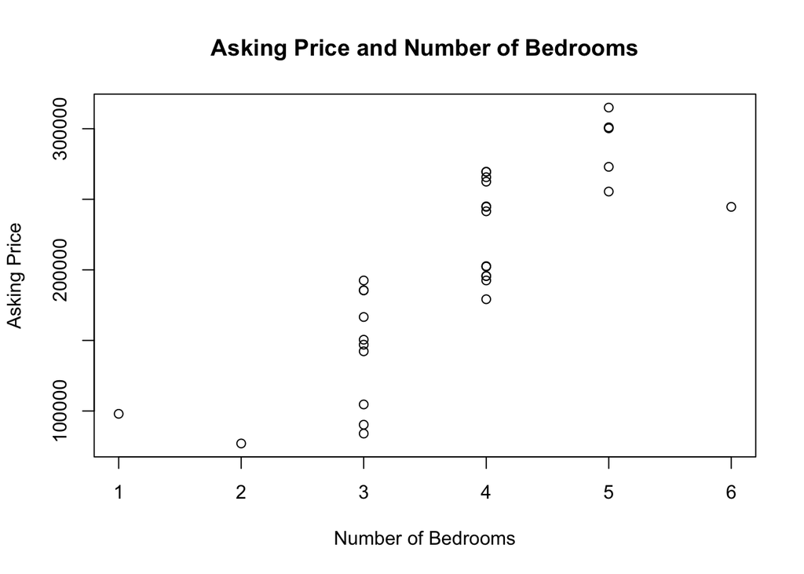

```r
plot(x = Housing$Bedrooms,                         # our x variable
     y = Housing$Price,                            # the y variable
     xlab = "Number of Bedrooms",                  # label the x-axis
     ylab = "Asking Price",                        # label the y-axis
     main = "Asking Price and Number of Bedrooms") # scatter diagram title
```

The scatter diagram above suggests a linearly increasing relationship between the **Price** and **Bedrooms** variables.

### Correlation and Test for Correlation

Correlation is a statistical measure that determines the strength of linear relationship between two variables. Correlation can take values between $-1$ and $+1$. The closer a correlation is to $-1$ or $+1$, the stronger the linear association between the variables.

Let’s test whether there is a significant correlation between the number of bedrooms in a house and the asking price for that house. Thus, we wish to test the hypotheses:
$$H_0:
\rho_{xy} = 0$$
$$H_a: \rho_{xy} \neq
0$$

To carry out the test, we will use the `cor_matrix()` function. This is a course-specific function written in base R, so no extra packages are needed. Base R’s `cor()` function gives the correlation matrix but not the $p$-values; `cor_matrix()` runs `cor.test()` on every pair of variables and prints the correlation matrix, the sample size, and a matching matrix of $p$-values. The `source()` line below loads the function from the course website (an internet connection is required). The input to `cor_matrix()` is a data set containing only the numeric variables we want to correlate.

```r
source("https://data-and-stats-course-hub.github.io/ITAO-20200/R-Guides-and-Codes/cor_matrix.R")
cor_matrix(Housing[, c("Price", "Bedrooms")])   # a table of x and y observations
```

```
## Correlation matrix
##          Price Bedrooms
## Price    1.000    0.815
## Bedrooms 0.815    1.000
##
## Sample Size
## [1] 31
##
## Probability values
##          Price Bedrooms
## Price        0        0
## Bedrooms     0        0
```

### Interpreting the Correlation Output

There are three parts to the output: `Correlation matrix`, `Sample Size`, and `Probability values`. The `Correlation matrix` provides us with information about the correlation between the variables. Technically, a variable is perfectly correlated with itself so finding the correlation between a variable and itself will result in a correlation value of $+1$. This is the information that we see on the diagonal of the `Correlation matrix` information in the output. The off-diagonal gives us the correlation between **Price** and **Bedrooms**. The matrix will always be symmetric (i.e., the upper diagonal values will always be the same as the lower diagonal values since they all provide the same information). The exact $p$-values for the correlation test are provided in the third part of the output, `Probability values`. Again, the diagonal gives us the $p$-values for the test of linear relationship between a variable and itself. This value will always be zero. The off-diagonal values on the other hand provide the $p$-value for testing for a significant linear relationship between the two variables. Similarly, the $p$-value matrix will always be symmetric. If the $p$-value is less than our alpha level (0.05 here), then we have determined that there is a statistically significant linear relationship between the dependent and independent variables. If this $p$-value is greater than our alpha level, then we retain the null hypothesis and state that the evidence is inconclusive. Our analysis produced a statistically significant linear relationship between **Price** and **Bedrooms**.

If you only need to test one pair of variables, `cor.test(Housing$Price, Housing$Bedrooms)` gives the same $p$-value along with the $t$ statistic, its degrees of freedom ($n - 2$), and a 95% confidence interval for $\rho_{xy}$.

## Fitting a Simple Linear Regression Model

Now that we have seen the linear relationship graphically in the scatter diagram, let’s go ahead and build our linear regression model. We will be using the `lm()` function (simply standing for **l**inear **m**odels) in R for building the model. The `lm()` function takes two main arguments: formula and data. For our data, the `lm()` function is utilized as follows:

```r
Housing_model <- lm(Price ~ Bedrooms, # Linear regression formula
                    data = Housing)   # Name of the dataset
```

We saved our model in an object called `Housing_model`. This makes it easier for us to reference the estimated model. We could use the `summary()` function to display the result of the model. However, this function does not automatically include the standardized coefficients in the estimated model. To do so, we will pass our model to the `ols_regress_mod()` function. This is a course-specific version of the `ols_regress()` function in the `olsrr` package; it corrects the MSE and RMSE in the Model Summary so that they agree with the Mean Square Residual in the ANOVA table. The `source()` line below loads the function from the course website (an internet connection is required), and it installs the `olsrr` package for you if you do not already have it.

```r
library(olsrr)
source("https://data-and-stats-course-hub.github.io/ITAO-20200/R-Guides-and-Codes/ols_regress_mod.R")
ols_regress_mod(Housing_model) # Use the name of your saved model as your input
```

```
##                               Model Summary
## --------------------------------------------------------------------------
## R                           0.815       RMSE                    39971.526
## R-Squared                   0.665       MSE                1597722896.942
## Adj. R-Squared              0.653       Coef. Var                  19.733
## Pred R-Squared              0.592       AIC                       748.854
## MAE                     33041.564       SBC                       753.156
## --------------------------------------------------------------------------
##  RMSE: Root Mean Square Error
##  MSE: Mean Square Error
##  MAE: Mean Absolute Error
##  AIC: Akaike Information Criteria
##  SBC: Schwarz Bayesian Criteria
##
##                                      ANOVA
## --------------------------------------------------------------------------------
##                         Sum of
##                        Squares        DF        Mean Square      F         Sig.
## --------------------------------------------------------------------------------
## Regression     91803711956.427         1    91803711956.427    57.459    0.0000
## Residual       46333964011.315        29     1597722896.942
## Total         138137675967.742        30
## --------------------------------------------------------------------------------
##
##                                        Parameter Estimates
## --------------------------------------------------------------------------------------------------
##       model         Beta    Std. Error    Std. Beta      t        Sig          lower        upper
## --------------------------------------------------------------------------------------------------
## (Intercept)    -4656.250     28264.137                 -0.165    0.870    -62462.901    53150.401
##    Bedrooms    55377.963      7305.629        0.815     7.580    0.000     40436.275    70319.651
## --------------------------------------------------------------------------------------------------
```

There are several information in the general output for analysing the estimated model. The output shows 3 components, including:

- `Model Summary:` Metrics used to assess how well the model fits our data.
- `ANOVA:` Provides an ANOVA table similar to the ones we obtained for One-way and Factorial ANOVAs.
- `Parameter Estimates:` Shows the estimated regression coefficients, their statistical significance, and estimated confidence intervals.

In what follows, we will try to interpret the components one at a time.

### Model Summary

The overall quality of the estimated linear regression model can be assessed using the diagnostic metrics displayed in the Model Summary portion of the output.

1. **$R$ (also known as Multiple $R$):** Multiple $R$ is the absolute value of the correlation between the actual scores, $y$, and the predicted scores, $\hat{y}$. In bivariate regression only, Multiple $R$ is equal to the absolute value of the correlation between $x$ and $y$, i.e. $|r_{xy}|$.
   $$R
   = \sqrt{R^2}$$
2. **$R^2$ (or Coefficient of Determination) and Adjusted $R^2$:** $R^2$ gives us information about the proportion of variability in the asking price (the dependent variable) that has been explained by the regression model with number of bedrooms (independent variable) as a predictor. For a simple linear regression, $R^2$ is the square of the correlation coefficient. Adjusted $R^2$ is a more conservative estimate of the model’s predictability. It is given by the formula:
   $$R^2=\frac{SSR}{SST}=1-\frac{SSE}{SST}\qquad\text{and}\qquad
   \text{Adj.}\ R^2 = R^2 - \left( 1- R^2\right)\left(\frac{p}{n-p-1}
   \right)$$
   where $p$ is the number of predictors and $n$ is the sample size. An $R^2$ or adjusted $R^2$ value that is close to 1 indicates that a large proportion of the variability in the dependent variable has been explained by the regression model. From our output, $R^2 = 0.665$ and Adjusted $R^2 = 0.653$ which indicate a good predictability of our model.
3. **Predicted $R^2$ (Pred R-Squared):** The predicted $R^2$ indicates how well a regression model predicts responses for new observations. We use this statistic to determine when the model fits the original data but is less capable of providing valid predictions for new observations.
4. **Root Mean Square Error (RMSE):** Also known as **residual standard error** or **standard error of the estimate (s)**. This quantity represents the average variation of the observations around the estimated regression line. This is sometimes known as the **standard deviation of the model**. In our model, $RMSE = 39971.526$, meaning that the observed asking prices deviate from the values on the regression line by approximately $39,971 on average.
   $$s=RMSE= \sqrt{MSE}$$
5. **Coefficient of Variation (Coef. Var):** In regression, we call the difference between the actual scores, $y$, and the predicted scores, $\hat{y}$, the $residuals$. The coefficient of variation for a model aims to describe the model fit in terms of the relative sizes of the squared residuals and actual scores. The lower the coefficient of variation, the smaller the residuals relative to the predicted value. This is suggestive of a good model fit.
6. **Mean Square Error (MSE):** The MSE is the average squared deviations between the actual scores, $y$, and the predicted scores, $\hat{y}$. It is also known as Mean Square Residual in the regression ANOVA table.
7. **Mean Absolute Error (MAE):** MAE is another measure of how well the model predicts the outcome variable. It is the average absolute deviation between the actual scores, $y$, and the predicted scores, $\hat{y}$.
   $$MAE
   = \frac{1}{n}\sum_{i=1}^{n}\left|y_i-\hat{y}_i\right|$$

### ANOVA Table

In a regression model, the ANOVA is used to determine how well a prediction model “fits” a data set. In other words, does our model have any significant predictors? Therefore, the null incorporates all the possible slopes in its description. Because there is only 1 predictor in bivariate regression, the null and alternative hypotheses for this $F$ test is simple:
$$H_0:\beta_1 = 0$$
$$H_a:\beta_1 \neq 0$$
Before we go through the ANOVA table output, let’s briefly go through the logic of the ANOVA $F$ test.

#### Logic of $F$ test: Bivariate Regression

For any score on the dependent variable:
$$y = \beta_0 + \beta_1 x + \varepsilon$$
Let’s consider the null hypothesis to be *true* for a moment. Then
$$y = \beta_0 + 0x + \varepsilon =
\beta_0 + \varepsilon$$

The independent variable disappers from the model, and all we are left with is an intercept and some random error. That is a worthless model – no predictability. If we retain the null hypothesis, then there are no statistically significant predictors in the model. If we reject the null, then at least one variable is useful in explaining the variation in our dependent variable. We have at least one *statistically significant predictor* (which is, as it turns out here, our only predictor).

Let’s go ahead and interpret our ANOVA source table from our output. The $F$ column gives us the obtained test statistic, and the $Sig.$ column indicates the exact one-tailed $p$-value of our obtained test statistic. If this $p$-value is less than our alpha level (0.05 here), then we have determined that we have at least one statistically significant predictor. In the ANOVA table portion of our output, our $F$ statistic is 57.459 with a corresponding $p$-value of 0.0000 which is less than our alpha level so we reject our null hypothesis.

### Parameter Estimates

The parameter estimates portion of the output shows:

- the variables in the model (i.e., `model` column),
- the estimates of the unstandardized (i.e., `Beta` column) and standardized (i.e., `Std. Beta` column) regression coefficients,
- the standard errors (`Std. Error` column), which defines the accuracy of the estimated unstandardized coefficients,
- the $t$ test statistic (`t` column) and associated $p$-value (in the `Sig` column) for testing statistical significance of estimates of the regression coefficients,
- the confidence interval for the coefficient estimates (in the `lower` and `upper` columns).

Our unstandardized regression line from the output is given as:
$$\hat{y} = -4656.25 + 55377.96x$$

and our standardized regression line is given as:

$$\hat{Z}_y = 0.815(Z_x)$$

#### Testing Coefficients for Statistical Significance

For a given predictor, the $t$ value and its associated $p$-value tests whether or not there is a statistically significant relationship between a given predictor and the outcome variable. That is, whether the regression coefficient of the predictor is significantly different from zero. The null and alternative hypotheses for such tests are as follows:
$$H_0: \beta_1 = 0$$
$$H_a: \beta_1 \neq 0$$

We evaluate it with a $t$ test:
$$t_\text{obt} = \frac{b_1}{\text{standard
error of } b_1}$$
We assess the $p$-value associated with the test with respect to our alpha level. If $p$-value is greater than alpha we retain the null, otherwise we reject the null. In our analysis, the $p$-value associated with **Bedrooms** is highly significant ($p$-value = $0.000 < 0.05$) so we reject the null and conclude that **Bedrooms** is a significant predictor of **Price**.

The confidence interval contains the range of scores in which we believe the true slope can be found. If the confidence interval contains zero (the null value), then it is a possible regression coefficient value. As such, the independent variable is not significant in predicting the outcome variable. If zero is outside the confidence interval, then we can conclude that the independent variable is a significant predictor of the outcome variable. Thus for our data, since zero is outside the confidence interval, we can conclude that number of bedrooms is a significant predictor of the asking price of a house.

## Practice on Your Own

Suppose now that we want to find whether there is a linear relationship between the **asking price** of a house and the **square footage** of that house. If this relationship exists, we want to build a prediction model based on the relationship.

1. Make a scatter diagram for the variables.
2. Find the correlation coefficient and test its significance using `cor_matrix()`.
3. Give a brief explanation of the type of relationship.
4. Perform a simple linear regression analysis and report your prediction model.
5. Report the ANOVA source table.
6. Evaluate and comment on the accuracy of your model.